# Module 02: Qualitative Roots and the Mixed-Methods Bridge

Computational Social Science — Graduate & Undergraduate

Course Instructor

2026-04-04

# 1 Why This Module Comes Before Methods

Students who come to this course primarily interested in machine learning, NLP, or statistical modelling sometimes find a module on qualitative methods unexpected. The positioning is deliberate. Every computational method in this course — factor analysis, topic modelling, latent class analysis, network analysis — ultimately depends on conceptual and interpretive decisions that are qualitative in nature:

- What constructs should our survey items measure? (qualitative judgment about what matters)
- What do topic model clusters actually *mean*? (requires reading text, not just inspecting word lists)
- Are our latent classes substantively meaningful or statistical artefacts? (requires knowledge of the phenomenon)
- What causal mechanism explains the network pattern we observe? (requires theoretical reasoning about social processes)

Computational methods can detect patterns in data at scales impossible for human readers. But they cannot tell you what those patterns mean, whether your measurement instruments are valid, or whether your findings are substantively important. That interpretive work is always qualitative, even when the methods are quantitative.

This module introduces qualitative research traditions not as alternatives to computational methods but as their necessary complement. It then introduces mixed-methods design — how to intentionally combine qualitative and quantitative approaches — and the bridge method called Computational Grounded Theory, which formalises how to move between them.

By the end of this module you should be able to:

- Describe the major qualitative research traditions and what each is good for
- Explain the difference between content analysis, discourse analysis, and ethnography
- Design a mixed-methods study using one of four established designs
- Apply Computational Grounded Theory’s three-step framework
- Compute basic inter-rater reliability in R
- Perform exploratory text analysis as Step 1 of the CGT framework
- Understand QCA as a configurational alternative to regression

# 2 Qualitative Research Traditions

## 2.1 Ethnography

Ethnography is the oldest and most immersive of the qualitative research traditions. The ethnographer enters a social setting — a neighbourhood, an organisation, a subculture, an online community — and participates in it over an extended period, observing what people do, listening to what they say, and developing an understanding of the setting from the inside. The anthropologist Clifford Geertz called this “thick description”: not just what happened but what it meant, in the full context of the social world in which it happened.

**What ethnography is good for:** Understanding social life as it actually unfolds, rather than as respondents reconstruct it retrospectively in a survey. Discovering unexpected patterns and social logics that the researcher did not anticipate. Studying contexts where direct questioning is inadequate — where social norms prohibit honest self-reporting, where behaviour is habitual and below conscious reflection, or where the relevant social processes are collective rather than individual.

**Limitations:** Small scale — one ethnographer in one setting over months or years. Limited generalisability. Highly dependent on the researcher’s positioning and judgment. Difficult to replicate.

**CSS connection:** Ethnographic knowledge is the conceptual foundation for computational measurement. Eubanks’ (2018) ethnographic work on algorithmic systems in public services revealed patterns of discrimination that neither quantitative analysis nor interview data would have discovered. Hochschild’s (2016) ethnographic work in Louisiana anticipated the political shifts that later appeared in large-scale survey data. Digital ethnography — immersive study of online communities — is an emerging CSS method.

## 2.2 In-Depth Interviews

In-depth interviews are conversations with a purpose. Unlike surveys, which impose the researcher’s categories and response options, interviews allow participants to answer in their own terms. A skilled interviewer uses a semi-structured guide — a set of topics and prompts — but follows the participant’s narrative, probing unexpected directions and allowing the participant to define what is significant.

The goal of interview research is to understand the participant’s subjective framework: how they make sense of their experience, what they consider relevant, and what categories and distinctions they use to organise their world. This is not simply about “getting their perspective” as if perspectives were self-evident — it requires careful analysis of what participants say, how they say it, what they avoid saying, and how they construct meaning through narrative.

**Grounded theory** (Glaser & Strauss 1967, Strauss & Corbin 1998) is the most widely used framework for interview analysis. It uses systematic coding — line-by-line labelling of what is happening in each passage — to build theoretical categories inductively from data. The key principle is *theoretical saturation*: you continue interviewing until new interviews stop generating new theoretical insights.

**CSS connection:** Interview-derived coding schemes often become the basis for computational text classifiers. If you want to classify 100,000 social media posts into categories of emotional expression, you need a validated set of emotional expression categories — and the best source for those categories is interview and ethnographic research about how people actually experience and express emotion in the relevant context.

## 2.3 Content Analysis

Content analysis is the systematic, replicable study of the content of communication. Unlike ethnography and interviews, which prioritise depth and context, content analysis prioritises comparability and replication — the ability to code the same material in the same way across raters, samples, and time.

A content analysis study begins with a **codebook**: a document specifying the units of analysis (individual posts, news articles, paragraphs, sentences), the categories to be coded, and operational definitions with examples for each category. The codebook must be sufficiently precise that two trained coders working independently reach the same conclusions when applied to the same material.

**Inter-rater reliability** is the formal measure of whether independent coders agree. The most common measures are:

- **Cohen’s kappa (κ):** Agreement corrected for chance agreement. Values > .70 are generally considered acceptable; > .80 is good; > .90 is excellent. Kappa of 0 means agreement no better than chance; kappa of 1 means perfect agreement.
- **Krippendorff’s alpha (α):** A more general reliability coefficient that handles ordinal and continuous coding, multiple coders, and missing data. Values > .667 are the minimum acceptable threshold.

Content analysis is the bridge between qualitative and computational text methods. Computational text analysis is, in essence, content analysis at scale — applying a coding scheme to vastly more text than human coders could handle. The validity of computational coding depends directly on the validity of the underlying content analytic framework.

## 2.4 Discourse Analysis

Discourse analysis treats language not just as a vehicle for communicating meaning but as a form of social action. When a politician describes an asylum seeker as an “illegal immigrant” rather than a “person seeking protection,” they are not just describing — they are categorising, evaluating, and positioning within a power structure. Discourse analysis asks: how does language construct social reality? Who benefits from particular ways of speaking? What is naturalised or made to seem inevitable through specific linguistic choices?

Foucauldian discourse analysis (after Michel Foucault) examines how discourses — organised systems of statements — produce the objects they appear to describe. Medical discourse does not just describe “mental illness” — it defines it, delimits it, and creates the institutional structures (hospitals, diagnoses, treatments) through which it is managed. Critical discourse analysis (Fairclough, Van Dijk) extends this to examine the relationship between language, power, and ideology in specific communicative events.

**CSS connection:** Framing analysis in political communication — the computational detection of how issues are defined and whose interests are served by different framings — is grounded in discourse analytic theory. The distinction between “death tax” and “estate tax,” or between “climate change” and “climate crisis,” is a discourse analytic observation that computational methods can then track at scale.

# 3 Mixed-Methods Design

## 3.1 Why Mix Methods?

No single method can answer all questions about a social phenomenon. Surveys give you population-level patterns but cannot tell you what those patterns mean. Experiments establish causation but at the cost of ecological validity. Ethnography reveals meaning and process but cannot generalise. Computational text analysis scales to millions of documents but loses the interpretive depth that human reading provides.

Mixed-methods research deliberately combines approaches so that each method compensates for the weaknesses of the others. A survey finding that social media use correlates with depression means more when combined with interview research showing *why* and *for whom* this relationship holds. A computational topic model is more interpretable when validated against manual coding and interview data about how participants themselves understand the topics.

Creswell and Plano Clark’s (2018) typology identifies four major mixed-methods designs:

Four Major Mixed-Methods Designs (after Creswell & Plano Clark, 2018)

| Design | Direction of Flow | When to Use | CSS Example |
| --- | --- | --- | --- |
| Sequential Explanatory | QUANT → qual | You have a quantitative finding that needs explanation. The qual phase explains what the quant found. | STM topic model identifies unexpected cluster → read documents in cluster → interpret meaning qualitatively |
| Sequential Exploratory | QUAL → QUANT | You need qualitative work to build the framework before quantitative scaling is possible. | Interviews identify dimensions of digital inequality → code scheme → apply classifier to 1M posts |
| Concurrent Triangulation | QUANT + QUAL simultaneously | You want to cross-validate findings from two independent data sources on the same phenomenon. | Survey + social media text about same political attitudes at same time → compare |
| Embedded | QUANT [qual] or QUAL [quant] | One method is primary; the other answers a specific sub-question that the primary cannot address. | Network study of information spread with embedded interview sub-sample about why people share |

## 3.2 The Validation Imperative

In any research that uses computational methods to classify, categorise, or score text or behaviour, **validation is not optional** — it is the most important step. A sentiment classifier that returns numbers without any evidence that those numbers measure what you intend them to measure is not an analytical tool; it is a number generator.

There are two kinds of validity that matter here:

**Construct validity:** Does the classifier measure the theoretical construct it is supposed to measure? A sentiment classifier trained on Amazon product reviews may not validly measure political sentiment in congressional speeches — the contexts, vocabularies, and pragmatic norms are different. Demonstrating construct validity requires comparing classifier output to some gold standard measure of the construct, such as expert human coding or an established scale.

**Ecological validity:** Does the classifier generalise to the population you are studying? A classifier trained on tweets from 2015 may not be valid for tweets from 2022, because language changes. A classifier trained primarily on English-language, US-origin text may not be valid for other linguistic communities.

In practice, validation typically involves: (1) selecting a random sample of documents, (2) having trained human coders code them using a validated codebook, (3) comparing coder agreement (reliability) and then comparing human codes to classifier output (validity). The gold standard is having multiple coders code each document and using averaged human judgment as the comparison.

# 4 Computational Grounded Theory

## 4.1 The Framework

Computational Grounded Theory (CGT) is Nelson’s (2020) formalisation of a mixed-methods text analysis approach. It synthesises the inductive, theory-building logic of grounded theory with the pattern-detection capacity of computational text methods. Its power lies in the explicit structure it provides for moving between computational patterns and qualitative interpretation.

> **Core reading:** Nelson, L.K. (2020). Computational grounded theory: A methodological framework. *Sociological Methods and Research*, 49(1), 3–42. https://doi.org/10.1177/0049124117729703

CGT has three steps:

**Step 1 — Computational Pattern Detection.** Use an unsupervised computational method — topic modelling, clustering, word embedding geometry — to identify patterns in a large corpus. The key discipline at this stage is to *not interpret* the patterns yet. You are identifying candidate structures in the data; whether those structures are meaningful is determined in Step 2.

**Step 2 — Qualitative Pattern Refinement.** Randomly sample documents from each computational pattern and read them carefully. Ask: what is actually happening in these documents? What themes emerge from close reading? Do the computational patterns correspond to meaningful social phenomena, or are they statistical artefacts? Use your qualitative reading to refine, merge, split, or abandon the computational categories.

**Step 3 — Computational Pattern Confirmation.** Operationalise the refined categories — either by developing a supervised classifier, a dictionary, or a refined unsupervised model — and apply it at scale. Test whether the refined categories predict theoretically meaningful outcomes. If they do, you have evidence that your categories are valid.

The abductive logic of CGT is what makes it powerful: you move from data (Step 1) to interpretation (Step 2) to confirmation (Step 3), revising your theoretical framework at each stage based on what you find. This is fundamentally different from either pure induction (just describe what the algorithm finds) or pure deduction (test pre-specified hypotheses without engaging with the data’s own structure).

## 4.2 Worked Example: Interview Data on Economic Insecurity

We work through the CGT logic with a small simulated corpus of interview segments. In real research, Step 1 would use a much larger corpus (thousands of documents); here we illustrate the analytical logic.

```r
# Simulated interview segments on economic disruption and community response
# In real research: actual transcripts, coded by trained researchers
interviews <- tibble(
  participant = rep(paste0("P", sprintf("%02d", 1:8)), each=2),
  segment_id  = 1:16,
  text = c(
    # P01
    "When the factory closed I didn't know what to do. Thirty years and then
     nothing. They handed you a box and that was it.",
    "My wife cried for a week. I didn't tell the kids right away. I thought
     maybe I'd find something fast. I didn't.",
    # P02
    "Our union tried to negotiate but management had already decided. By the
     time we voted on the contract it was already done.",
    "I felt like the ground had been pulled out. Like everything I'd built my
     identity around just disappeared overnight.",
    # P03
    "The food bank was run by people from the church. Nobody made you feel
     small about it. That mattered.",
    "People started growing vegetables in their yards. Sharing. The neighbourhood
     actually got tighter in some ways.",
    # P04
    "Government retraining programs — they were a joke. Office work, coding.
     At fifty-five? With my hands? What was I supposed to do with that?",
    "I tried the community college. The other students were my kids' age.
     I lasted six weeks.",
    # P05
    "I felt ashamed. Like I had failed my family. Even though I knew it wasn't
     my fault, I felt it was my fault. That's what it does to you.",
    "My blood pressure went through the roof. I couldn't afford the doctor.
     I just didn't go.",
    # P06
    "There was a community meeting at the VFW hall. Hundreds of people. It was
     the first time I understood we were all in it together.",
    "We organised a food co-op, a tool lending library. Small things but they
     meant something.",
    # P07
    "When you've worked hard your whole life and then someone in an office
     somewhere makes a decision and your life just — stops —",
    "I voted differently after that. I don't know if it was right or wrong but
     I needed to vote for someone who seemed angry about it.",
    # P08
    "The town is different now. You can feel it. The storefronts are empty.
     The school is smaller.",
    "But there's something else. People talk to each other more. I don't know
     how to explain it. Something changed."
  ),
  # Human-assigned qualitative codes (Step 2 output in real CGT)
  code = c(
    "economic_loss","shame_concealment",
    "labour_politics","identity_disruption",
    "mutual_aid","community_solidarity",
    "policy_failure","policy_failure",
    "shame_concealment","health_consequences",
    "community_solidarity","mutual_aid",
    "political_alienation","political_alienation",
    "community_change","community_change"
  ),
  age    = rep(c(54,58,47,52,61,49,55,43), each=2),
  gender = rep(c("F","M","F","M","M","F","M","F"), each=2)
)

cat("Simulated corpus:\n")
```

```
## Simulated corpus:
```

```r
cat("  Participants:", n_distinct(interviews$participant), "\n")
```

```
##   Participants: 8
```

```r
cat("  Segments:", nrow(interviews), "\n")
```

```
##   Segments: 16
```

```r
cat("  Codes assigned:", n_distinct(interviews$code), "\n\n")
```

```
##   Codes assigned: 10
```

```r
print(table(interviews$code))
```

```
##
##     community_change community_solidarity        economic_loss
##                    2                    2                    1
##  health_consequences  identity_disruption      labour_politics
##                    1                    1                    1
##           mutual_aid       policy_failure political_alienation
##                    2                    2                    2
##    shame_concealment
##                    2
```

### 4.2.1 Step 1: Computational Pattern Detection

We run LDA to identify patterns *without using our a priori codes*. The question is whether the algorithm recovers something similar to what human coders found.

```r
library(tidytext)
library(topicmodels)

# Tokenize the interview text
interview_tokens <- interviews |>
  unnest_tokens(word, text) |>
  anti_join(stop_words, by="word") |>
  filter(nchar(word) > 2,
         !word %in% c("people","thing","things","just","felt","like",
                      "didn","couldn","wasn","time","make","made"))

# Most frequent content words
word_freq <- interview_tokens |>
  count(word, sort=TRUE)

# Build document-term matrix for LDA
dtm <- interview_tokens |>
  count(participant, word) |>
  cast_dtm(participant, word, n)

# Fit LDA with K=4 topics (we use K=4 to see if it maps to major code clusters)
set.seed(2024)
lda4 <- LDA(dtm, k=4, method="Gibbs",
            control=list(seed=2024, burnin=500, iter=1000, thin=5))

# Step 1 output: TOP TERMS PER TOPIC — do NOT interpret yet
cat("=== STEP 1: COMPUTATIONAL PATTERNS (top 8 terms per topic) ===\n")
```

```
## === STEP 1: COMPUTATIONAL PATTERNS (top 8 terms per topic) ===
```

```r
cat("At this stage, resist the urge to name the topics.\n")
```

```
## At this stage, resist the urge to name the topics.
```

```r
cat("These are candidate patterns that Step 2 will interpret.\n\n")
```

```
## These are candidate patterns that Step 2 will interpret.
```

```r
top_terms <- tidy(lda4, matrix="beta") |>
  group_by(topic) |>
  slice_max(beta, n=8) |>
  ungroup()

print(top_terms |>
  select(topic, term, beta) |>
  mutate(beta=round(beta,4)) |>
  pivot_wider(names_from=topic, values_from=beta,
              names_prefix="Topic_") |>
  arrange(desc(Topic_1)))
```

```
## # A tibble: 84 × 5
##    term      Topic_1 Topic_2 Topic_3 Topic_4
##    <chr>       <dbl>   <dbl>   <dbl>   <dbl>
##  1 feel       0.0629      NA      NA      NA
##  2 office     0.0629      NA      NA      NA
##  3 box        0.0329      NA      NA      NA
##  4 thirty     0.0329      NA      NA      NA
##  5 week       0.0329      NA      NA      NA
##  6 built      0.0329      NA      NA      NA
##  7 decided    0.0329      NA      NA      NA
##  8 overnight  0.0329      NA      NA      NA
##  9 pulled     0.0329      NA      NA      NA
## 10 union      0.0329      NA      NA      NA
## # ℹ 74 more rows
```

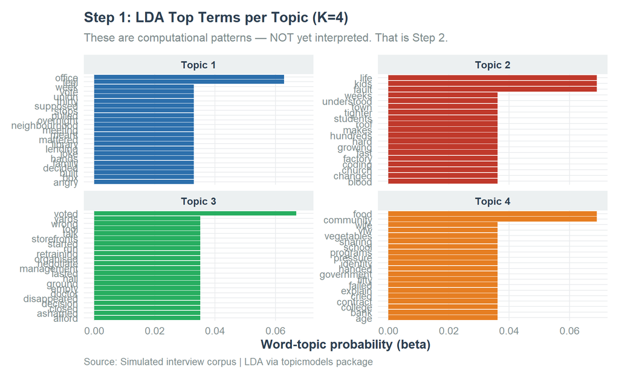

```r
ggplot(top_terms, aes(x=beta, y=reorder_within(term, beta, topic),
                      fill=factor(topic))) +
  geom_col(show.legend=FALSE) +
  facet_wrap(~paste("Topic", topic), scales="free_y") +
  scale_y_reordered() +
  scale_fill_manual(values=css_palette(4)) +
  labs(
    title    = "Step 1: LDA Top Terms per Topic (K=4)",
    subtitle = "These are computational patterns — NOT yet interpreted. That is Step 2.",
    x = "Word-topic probability (beta)", y = NULL,
    caption  = "Source: Simulated interview corpus | LDA via topicmodels package"
  )
```

### 4.2.2 Step 2: Qualitative Refinement — Reading the Documents

This is the step that most computational researchers skip. It is also the most important.

```r
# Assign each participant to their dominant topic
doc_topics <- tidy(lda4, matrix="gamma") |>
  group_by(document) |>
  slice_max(gamma, n=1) |>
  ungroup() |>
  rename(participant=document, dominant_topic=topic)

# Join back to interview data
interviews_with_topics <- interviews |>
  left_join(doc_topics |>
    group_by(participant) |>
    slice_max(gamma, n=1, with_ties=FALSE) |>
    select(participant, dominant_topic, gamma),
    by="participant")

cat("=== STEP 2: READING DOCUMENTS PER TOPIC ===\n")
```

```
## === STEP 2: READING DOCUMENTS PER TOPIC ===
```

```r
cat("For each topic, read randomly selected segments.\n")
```

```
## For each topic, read randomly selected segments.
```

```r
cat("Ask: What is actually happening here? What does this mean to the speaker?\n\n")
```

```
## Ask: What is actually happening here? What does this mean to the speaker?
```

```r
for (t in 1:4) {
  cat(paste0("--- Topic ", t, " ---\n"))
  # Show 2 sample segments from participants dominant in this topic
  sample_segs <- interviews_with_topics |>
    filter(dominant_topic == t) |>
    slice_head(n=2)
  for (i in seq_len(nrow(sample_segs))) {
    cat(paste0("[", sample_segs$participant[i], " | Code: ",
               sample_segs$code[i], "]\n"))
    # Word-wrap the text for readability
    cat(strwrap(sample_segs$text[i], width=70, indent=2,
                exdent=2), sep="\n")
    cat("\n")
  }
}
```

```
## --- Topic 1 ---
## [P01 | Code: economic_loss]
##   When the factory closed I didn't know what to do. Thirty years and
##   then nothing. They handed you a box and that was it.
##
## [P01 | Code: shame_concealment]
##   My wife cried for a week. I didn't tell the kids right away. I
##   thought maybe I'd find something fast. I didn't.
##
## --- Topic 2 ---
## [P05 | Code: shame_concealment]
##   I felt ashamed. Like I had failed my family. Even though I knew it
##   wasn't my fault, I felt it was my fault. That's what it does to
##   you.
##
## [P05 | Code: health_consequences]
##   My blood pressure went through the roof. I couldn't afford the
##   doctor.  I just didn't go.
##
## --- Topic 3 ---
## [P08 | Code: community_change]
##   The town is different now. You can feel it. The storefronts are
##   empty.  The school is smaller.
##
## [P08 | Code: community_change]
##   But there's something else. People talk to each other more. I don't
##   know how to explain it. Something changed.
##
## --- Topic 4 ---
## [P03 | Code: mutual_aid]
##   The food bank was run by people from the church. Nobody made you
##   feel small about it. That mattered.
##
## [P03 | Code: community_solidarity]
##   People started growing vegetables in their yards. Sharing. The
##   neighbourhood actually got tighter in some ways.
```

After reading, we would label the topics interpretively. In real research, this step involves: (a) reading all documents in each topic, not just two; (b) writing memos about what you observe; (c) comparing your interpretation with other members of the research team; (d) possibly splitting or merging topics based on what you find.

### 4.2.3 Step 3: Confirmation — Does the Validated Category Predict Outcomes?

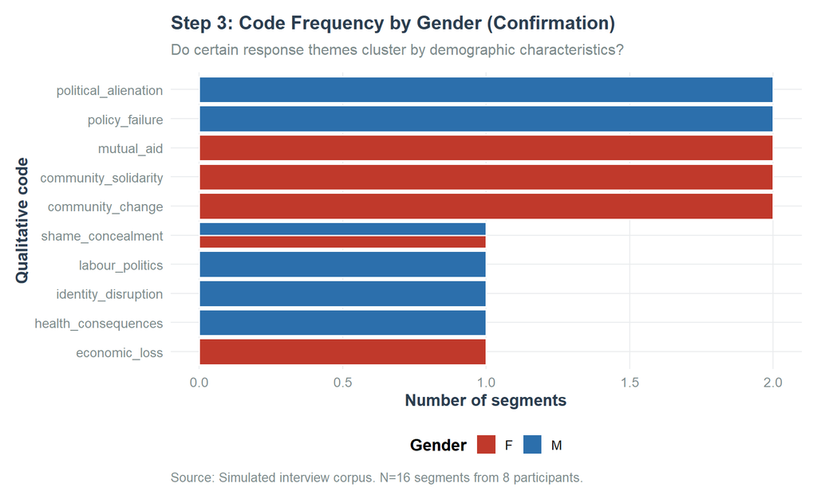

```r
# In Step 3, we test whether our refined categories predict meaningful outcomes
# Here: do interview participants who discuss political alienation show
# different age/gender profiles than those focused on mutual aid?

# Compare code distributions across participant demographics
code_summary <- interviews |>
  group_by(code, gender) |>
  summarise(
    n          = n(),
    mean_age   = round(mean(age), 1),
    .groups = "drop"
  ) |>
  arrange(code, gender)

ggplot(code_summary, aes(x=reorder(code, n), y=n, fill=gender)) +
  geom_col(position="dodge", colour="white") +
  scale_fill_manual(values=c("F"="#C0392B","M"="#2C6FAC"),
                    name="Gender") +
  coord_flip() +
  labs(
    title    = "Step 3: Code Frequency by Gender (Confirmation)",
    subtitle = "Do certain response themes cluster by demographic characteristics?",
    x = "Qualitative code", y = "Number of segments",
    caption  = "Source: Simulated interview corpus. N=16 segments from 8 participants."
  )
```